# Perception of Scientific Visualization

Steve Elston

12/26/2020

# Why This Course?

- **Data science** is the science of **understanding data**
- Statistics is the science of making **principled inferences** from data
  - Inference leads to understanding
  - Inference is becoming harder with large complex data sets
- Doing rigorous data science requires understanding statistics

# Course Objectives

- Broad introduction to the theoretical and methodological basis of data science.
  - Data exploration and visualization
  - Probability theory
  - Statistical theory
  - Theory or linear statistical models
- Understand the basis of core machine learning algorithms
  - How these methods work
  - Why these methods fail
  - What to do when things go wrong
- Moving beyond cookbook or blog post approach to data science

# Grading

| Activity | Grade weight |
| --- | --- |
| Participation (in-class and discussion board activity$^*$) | 20% |
| Quizzes | 20% |
| Assignments and milestones | 60% |

$^*$ at least 20 posts in Piazza on discussion questions, class materials, answering other students questions. Also, responding to polls and discussion questions in class.

# Instructor: Steve Elston

- Data science consultant with several decades of experience
- Lead team that commercialized Bell Labs S, now open source R
- Company co-founder and held executive positions in several industries
- Creator of multiple edX courses, author of O’Reily books and articles
- Holder of several patents
- BS, physics and math (minor), University of New Mexico
- MS and PhD, geophysics, Princeton University – John von Neuman Supercomputing Fellow

# Teaching Fellow: Kyle Assano

- Graduated in Mechanical Engineering, Santa Clara University
- Completed Data Science certificate program
- Area of interest: Business and Healthcare

# Communications

Communicating with your instructors and other students is a significant aspect of participation in this course!

- Ask questions about the course material, homework, etc.
- Ask questions in the public forum so others can answer and gain from the discussion: if you have a question others do as well!
- Answer other students’ questions
- Comment on weekly discussion topics

Piazza is the primary communications method and you are **required to sign up for the course Piazza forum**  
- piazza.com/washington/winter2021/datasci520cswi21  
- Pass code: DS520_2021

# Communications

For private matters, you can directly communicate with the instructional team:

Steve Elston, Instructor, stephen.elston@quantia.com  
Kyle Assano, TF, asano.kyle@gmail.com

- Grades
- Absences
- Etc

Communications by Canvas may be **significantly delayed!**

# Poll

Then, back to the lecture

# Why Exploration and Visualization?

- Why not just start building machine learning models?
- Understanding relationships in data saves missteps and unexplained poor model performance
  - Which variables are actually important?
  - How do these variables behave?
  - Are there errors and outliers in the data?
- Communications is an important component of data science
  - Analytic results are only useful if they are understood and trusted
  - Graphical presentation greatly assists understanding by less technical colleagues

# Why is Perception Important?

- **Goal:** Communicate information visually
- Visualization technique maximize the information a viewer perceives
- limits of human perception are a significant factor in understanding complex relationships
- Can apply results of the considerable research on human perceptions for data visualization

# Use Aesthetics to Improve Perception

- Use aesthetics to improve perception
- We take a very broad view of the term ‘aesthetic’ here
- A plot aesthetics is any property of a visualization which highlight aspects of the data relationships
- Aesthetics are used to project additional dimensions of complex data onto the 2-dimensional plot surface

# Organization of Plot Aesthetics

We can organize aesthetics by their effectiveness:

1. **Easy to perceive plot aesthetics:** help most people gain understanding of data relationships
2. **Aesthetics with moderate perceptive power:** useful properties to project data relationships when used sparingly
3. **Aesthetics with limited perceptive power:** useful within strict limits

# Properties of Common Aesthetics

| Property or Aesthetic | Perception | Data Types |
| --- | --- | --- |
| Aspect ratio | Good | Numeric |
| Regression lines | Good | Numeric plus categorical |
| Marker position | Good | Numeric |
| Bar length | Good | Counts, numeric |
| Sequential color palette | Moderate | Numeric, ordered categorical |
| Marker size | Moderate | Numeric, ordered categorical |
| Line types | Limited | Categorical |
| Qualitative color palette | Limited | Categorical |
| Marker shape | Limited | Categorical |
| Area | Limited | Numeric or categorical |
| Angle | Limited | Numeric |

# Aspect Ratio

- **Aspect ratio** has a significant influence on how a viewer perceives a chart
- Correct aspect ratio can help highlight important relationships in complex data sets
- We express aspect ratio as follows:

$$aspect\ ratio = \frac{width}{height}\ : 1$$

- **Banking angle** is key to understanding how the aspect ratio affects perception

# Example of Changing Aspect Ratio

- Longest scientific time series is the sunspot count

```
##      YEAR  SUNACTIVITY
## 0  1700.0          5.0
## 1  1701.0         11.0
## 2  1702.0         16.0
## 3  1703.0         23.0
## 4  1704.0         36.0
```

Example of Changing Aspect Ratio

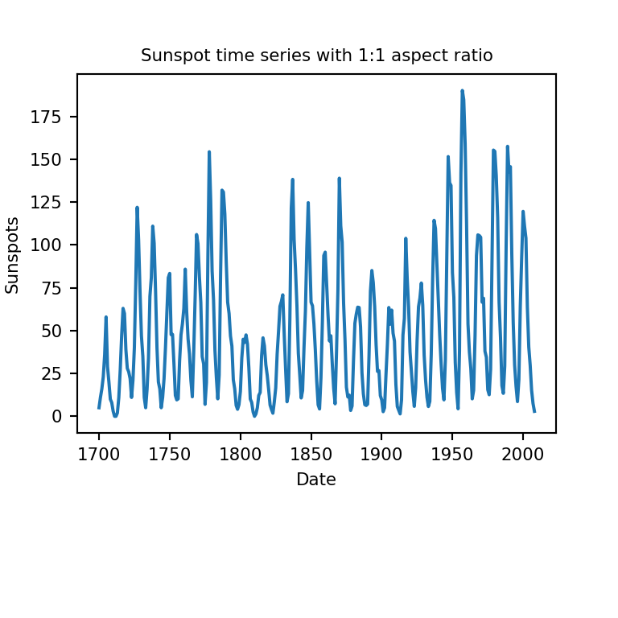

# Example of Changing Aspect Ratio

- Notice how changing aspect ratio change perception of the asymmetry?

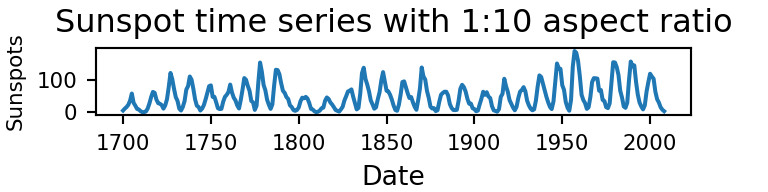

# Sequential and Divergent Color Palettes

Use of **color** as an aesthetic in visualization is a complicated subject.

- color is often used, also often abused
- A **qualitative palette** is a palette of individual colors to display categorical values
- **Sequential palettes** and **divergent palettes** are a sequence of colors used to display a quantitative variable or ordered categorical variable